# MH3511 Lab 10 Notes

Caleb Tay (caleb.tay@ntu.edu.sg)

16 Apr 2026

# Exercise 10.1

```r
bef = c(54, 25, 82, 76, 63, 82, 94, 72, 33, 90)
aft = c(68, 42, 80, 91, 70, 88, 90, 81, 38, 93)
```

We have data on the scores of favourability towards peoples jobs. There is a dependence between the before and after scores, so a paired test is appropriate. It is similar to the McNemar test - that tested a change in proportions, but here, we are testing for a change in magnitude.

We have $H_0:$ a flexible workday has no effect on employees’ favourability of their job, and $H_1:$ a flexible workday has a positive effect on employees’ favourability of their job.

The sign test tests whether there is a positive or negative effect overall, but not the magnitude. The idea is essentially the same as the McNemar test - if there was no real effect, we would expect the same number to increase and decrease. With a statistical lens, if $T$ is the number of positive changes, we have $T \sim \mathrm{Bin}(10, 0.5)$.

We have 10 observations, 8 of which are positive. Since this is a one-tailed test, what is the probability of getting 8 or more positive changes?

$$P(T \geq 8) = 1 - P(T < 8) = 1 - P(T <= 7)$$

```r
n <- length(bef)
diff <- aft - bef
pos <- sum(diff > 0)

1-pbinom(pos-1, n, 0.5)
```

```
## [1] 0.0546875
```

```r
prop.test(pos, n, alternative = "greater")
```

```
##
##  1-sample proportions test with continuity correction
##
## data:  pos out of n, null probability 0.5
## X-squared = 2.5, df = 1, p-value = 0.05692
## alternative hypothesis: true p is greater than 0.5
## 95 percent confidence interval:
##  0.4899781 1.0000000
## sample estimates:
##   p
## 0.8
```

The sign test may fail to be rejected if there are a roughly equal amount of large positive changes and small negative changes. The Wilcoxon signed rank sum test takes into account the magnitude of the change, catching such a scenario.

The distribution of the test statistic is similar to the Wilcoxon rank sum test.

```r
wilcox.test(aft, bef, paired=T, exact=T, alternative="greater")
```

```
##
##  Wilcoxon signed rank exact test
##
## data:  aft and bef
## V = 51, p-value = 0.006836
## alternative hypothesis: true location shift is greater than 0
```

```r
# prop.test(10, 20, 0.5, alternative="greater")
bef <- rep(0, 20)
aft <- c(-10:-1, 11:20)
bef; aft
```

```
##  [1] 0 0 0 0 0 0 0 0 0 0 0 0 0 0 0 0 0 0 0 0
```

```
##  [1] -10  -9  -8  -7  -6  -5  -4  -3  -2  -1  11  12  13  14  15  16  17  18  19
## [20]  20
```

```r
wilcox.test(aft, bef, paired=T, exact=T, alternative="greater")
```

```
##
##  Wilcoxon signed rank exact test
##
## data:  aft and bef
## V = 155, p-value = 0.03186
## alternative hypothesis: true location shift is greater than 0
```

# Exercise 10.2

The hypothesis to test is given in the question statement. We have $H_0:$ the birth rate is constant over all four seasons, and $H_1:$ there is some difference in the birth rates between seasons.

We have 4 seasons and 7 hospitals - and we are interested in testing whether there is an effect between the **seasons** , and so must consider **the rankings of the seasons** within the hospitals, which represents the variance within each season.

Here, a one-way ANOVA is not appropriate for two reasons: the data in each group is not independent (linked by the hospitals), and the data doesn’t seem to be normally distributed (just by looking at the values).

```r
hospitals <- c("A", "B", "C", "D", "E", "F", "G")
hospital <- rep(hospitals, 4)
season <- rep(c("Winter", "Spring", "Summer", "Fall"), rep(7, 4))
winter <- c(92, 9, 98, 19, 21, 58, 42)
spring <- c(112, 11, 109, 26, 22, 71, 49)
summer <- c(94, 10, 92, 19, 23, 51, 44)
fall <- c(77, 12, 81, 18, 24, 62, 41)
births <- c(winter, spring, summer, fall)

births <- data.frame(hospital, season, births)
births <- births[order(births$hospital),]

rowrank <- NULL
for (i in hospitals) { rowrank <- c(rowrank, rank(births[births$hospital==i, "births"])) }
births$rowrank <- rowrank

ranksum <- aggregate(rowrank ~ season, FUN=sum, data=births)
ranksum
```

```
##   season rowrank
## 1   Fall    15.0
## 2 Spring    25.0
## 3 Summer    16.5
## 4 Winter    13.5
```

The test statistic is:

$$T = \frac{(k-1) n (B - nk(k + 1)^2 / 4)}{A - nk(k+1)^2 / 4}$$

where

$$A = \sum_{i, j} R^2(X_{ij}), B = \frac{1}{n}\sum_j R^2_j$$

which is similar to the ANOVA test.

```r
friedman.test(births ~ season | hospital, data = births)
```

```
##
##  Friedman rank sum test
##
## data:  births and season and hospital
## Friedman chi-squared = 6.913, df = 3, p-value = 0.07472
```

# Exercise 10.3

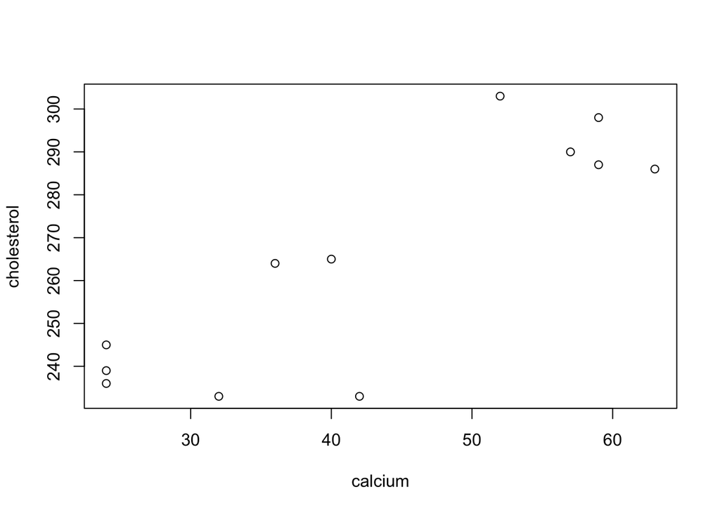

```r
calcium <- c(59, 52, 42, 59, 24, 24, 40, 32, 63, 57, 36, 24)
cholesterol <- c(298, 303, 233, 287, 236, 245, 265, 233, 286, 290, 264, 239)

plot(calcium, cholesterol)
```

```r
var.x <- var(calcium)
var.y <- var(cholesterol)
var.xy <- cov(calcium, cholesterol)
```

The definition of correlation is:

$$\rho = \frac{\mathrm{Cov}(X, Y)}{\sqrt{\mathrm{Var}(X) \mathrm{Var}(Y)}}$$

It is symmetric, so there is no worry in calculating it with $\mathrm{Cov}(Y, X)$ instead. A side note on notation: you may see the population correlation denoted with $\rho$ and the sample correlation denoted with $r$.

```r
cor(calcium, cholesterol)
```

```
## [1] 0.8573301
```

```r
cor.xy <- var.xy / sqrt(var.x * var.y); cor.xy
```

```
## [1] 0.8573301
```

The distribution of $r$ is complicated, but under $H_0: \rho = 0$, we have two possible test statistics. The first is that $t = \frac{r}{s_r}$ is t-distributed with $n-2$ degrees of freedom, where $s_r = \sqrt{\frac{1-r^2}{n-2}}$. This is derived from the coefficient of the slope in a linear regression.

The second is that $F = \frac{1+|r|}{1-|r|}$ is F-distributed with $n-2$ degrees of freedom in both the numerator and denominator.

The first test is a two-tailed test, $H_0: \rho = 0$ against $H_1: \rho \neq 0$.

```r
n <- length(calcium)
s.r <- sqrt((1 - cor.xy^2) / (n - 2))
t.stat <- cor.xy / s.r; t.stat
```

```
## [1] 5.266686
```

```r
(1 - pt(t.stat, n-2)) * 2
```

```
## [1] 0.0003645416
```

The second test is a one-tailed test, $H_0: \rho = 0$ against $H_1: \rho > 0$.

```r
f.stat <- (1 + abs(cor.xy)) / (1 - abs(cor.xy))
(1 - pf(f.stat, n-2, n-2))
```

```
## [1] 0.0001822708
```

The distributions above only hold for $\rho = 0$. For any other values, we use Fisher’s transformation: $z = \frac12 \ln\left( \frac{1+r}{1-r} \right) = \mathrm{arctanh}(r)$, so that $z$ is normally distributed. The standard deviation is $\sqrt{1/(n-3)}$.

$$\fbox{Correlation space $[-1, 1]$: $\rho, \rho_0$} \longleftrightarrow
\fbox{Z-space $(-\infty, +\infty)$: $z, z_0$}$$

We essentially have a link between these two spaces: the correlation space, which is what we are interested in, and Z-space, which we know the distribution of. We can take values from the correlation space, transform them to Z-space to get a confidence interval (still in Z-space) or p-value (which is space-invariant), and transform back values from Z-space to correlation space as needed.

$$H_0: \rho = \rho_0 \implies
Z = \frac12 \ln \left( \frac{1+r}{1-r} \right) \sim
N\left( \frac12 \ln\left( \frac{1+\rho_0}{1-\rho_0}\right),
\frac{1}{n-3} \right)$$

```r
rho0 <- 0.5
# z0 <- log((1 + rho0)/(1-rho0)) / 2
z0 <- atanh(rho0)

# z <- log((1+cor.xy)/(1-cor.xy)) / 2
z <- atanh(cor.xy)

s.z <- sqrt(1/(n-3))

1 - pnorm(z, z0, s.z)
```

```
## [1] 0.01384592
```

$$Z = \frac12 \log \left( \frac{1+\rho}{1-\rho} \right) =
\mathrm{arctanh}(\rho)
\\ e^{2Z} = \left( \frac{1+\rho}{1-\rho} \right)
\\ e^{2Z} (1-\rho) = 1+\rho
\\ e^{2Z} - \rho e^{2Z} = 1 + \rho
\\ e^{2Z} - 1 = \rho e^{2Z} + \rho = \rho(e^{2Z} + 1)
\\ \rho = \frac{e^{2Z}-1}{e^{2Z}+1} = \tanh(Z)$$

So, we create a confidence interval in the Z-space, but want to express it as a confidence interval in the correlation space, so we transform it back.

```r
conf.l <- qnorm(0.025, z, s.z)
conf.u <- qnorm(0.975, z, s.z)
conf <- c(conf.l, conf.u)

(exp(2*conf) - 1) / (exp(2*conf) + 1)
```

```
## [1] 0.5579556 0.9592557
```

```r
tanh(conf)
```

```
## [1] 0.5579556 0.9592557
```

We can get the same p-value and confidence interval using `cor.test()`.

```r
cor.xy
```

```
## [1] 0.8573301
```

```r
cor.test(calcium, cholesterol, conf.level=0.95)
```

```
##
##  Pearson's product-moment correlation
##
## data:  calcium and cholesterol
## t = 5.2667, df = 10, p-value = 0.0003645
## alternative hypothesis: true correlation is not equal to 0
## 95 percent confidence interval:
##  0.5579556 0.9592557
## sample estimates:
##       cor
## 0.8573301
```

# Exercise 10.4

```r
rent <- read.table("rent.txt", header=T)
cor.test(rent$rent, rent$size)
```

```
##
##  Pearson's product-moment correlation
##
## data:  rent$rent and rent$size
## t = 7.7404, df = 23, p-value = 7.518e-08
## alternative hypothesis: true correlation is not equal to 0
## 95 percent confidence interval:
##  0.6850170 0.9321097
## sample estimates:
##       cor
## 0.8500608
```

The model that we get is $\mathrm{rent} = 177.121 + 1.065 \times \mathrm{size}$, which we can see from the summary output. Note that the t-value and p-value are the same as the test above.

```r
rent.m <- lm(rent ~ size, data=rent)
summary(rent.m)
```

```
##
## Call:
## lm(formula = rent ~ size, data = rent)
##
## Residuals:
##     Min      1Q  Median      3Q     Max
## -442.26  -58.86  -15.42  104.17  365.13
##
## Coefficients:
##             Estimate Std. Error t value Pr(>|t|)
## (Intercept) 177.1208   161.0043    1.10    0.283
## size          1.0651     0.1376    7.74 7.52e-08 ***
## ---
## Signif. codes:  0 '***' 0.001 '**' 0.01 '*' 0.05 '.' 0.1 ' ' 1
##
## Residual standard error: 194.6 on 23 degrees of freedom
## Multiple R-squared:  0.7226, Adjusted R-squared:  0.7105
## F-statistic: 59.91 on 1 and 23 DF,  p-value: 7.518e-08
```

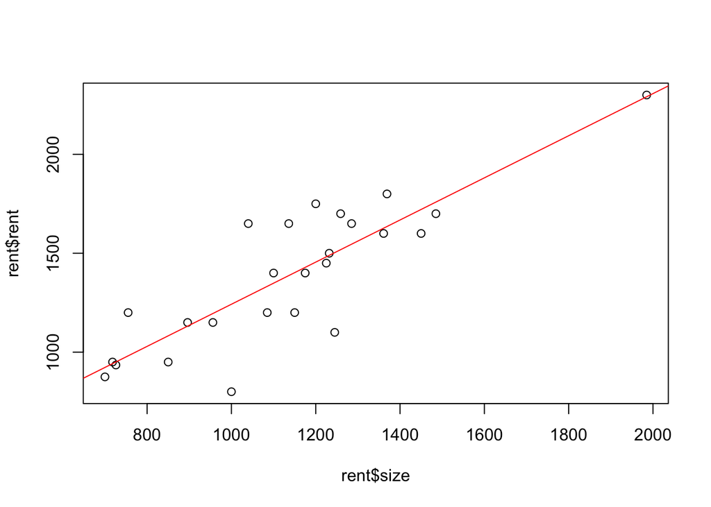

```r
plot(rent$size, rent$rent)
abline(rent.m, col="red")
```